# UML

##### Interfaces

Una interfaz, de forma similar a una clase abstracta, no tendrá instancias.

Una interfaz representa un contrato. Las clases que participen en este contrato, es decir, que implementan esta interfaz, se obligan a sí mismas a implementar el comportamiento especificado en la interfaz.

Se especifica indicando en la cabecera del nombre *interface*.

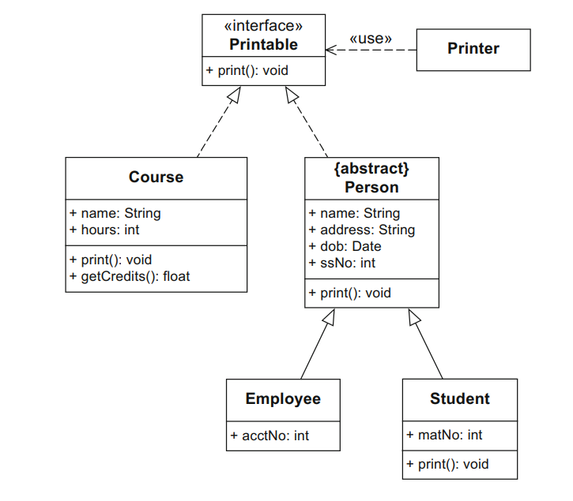

En el ejemplo anterior, las clases Person y Course implementan la interfaz Printable (imprimible) para ello utiliza la flecha punteada parecida a la herencia. En el caso de la línea dirigida puntea con la leyenda use lo que denotamos es esa clase utiliza la interfaz Printable.

Tipos de datos

Los atributos, los parámetros y los return operaciones tienen un tipo. Este tipo puede ser una clase del modelo, o un tipo de dato más general.

En UML hay 4 tipos primitivos de datos: Boolean, Integer, UnlimitedNatural, String. Aquéllo tipos que el usuario necesite definir llevarán la *primitive*. Los tipos primitivos sólo pueden tener operaciones que se ejecuten sobre el valor del tipo.

Por otro lado, si se van a tener varios atributos, no es un sólo valor, el tipo se declarará mediante *datatype*. Las enumeraciones son tipos de datatype particularizados a una lista de valores permitidos.

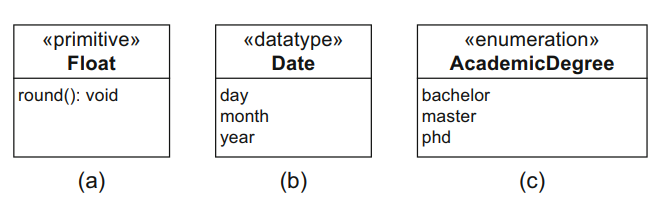

Creación de un diagrama de clases UML

UML va a describir la sintaxis y la semántica de clases y sus relaciones (asociaciones), pero no cómo las clases y las relaciones son construidas.

Guía para extraer un modelo:

- Nombres como persona, empleado, curso, etc a menudo indican una clase.
- En cambio nombres como Pablo, orientación a objeto y expresiones que indican relaciones entre posibles clases, raramente son clases.
- Aspectos importantes:
  - ¿qué operaciones un objeto de una clase puede realizar?
  - ¿qué eventos, para los cuales el objeto puede tener que reaccionar, pueden ocurrir?
  - ¿qué otros eventos pueden ocurrir como resultado?

Ejemplo

Una universidad consiste de múltiples facultades las cuales se componen de varios institutos universitarios. Cada facultad y cada instituto tiene un nombre. Cada instituto tiene una dirección.

Cada facultad es dirigida por un rector, que es un empleado de la universidad. El número total de empleados se conoce. Los empleados tienen un número de la seguridad social, un nombre y una dirección de e-mail. Hay una distinción entre personal investigador y administrativo.

Los investigadores se asignan al menos a un instituto. El campo de estudio de cada investigador se conoce. Por otro lado, investigadores pueden estar involucrados en proyectos por un cierto número de horas, y el nombre, la fecha de inicio, y final del proyecto se conocen. Algunos investigadores imparten también cursos. Se llaman ponentes.

Los cursos tienen un único número(ID), un nombre, y una duración semanal en horas.

Pasos:

- Identificación de las clases.

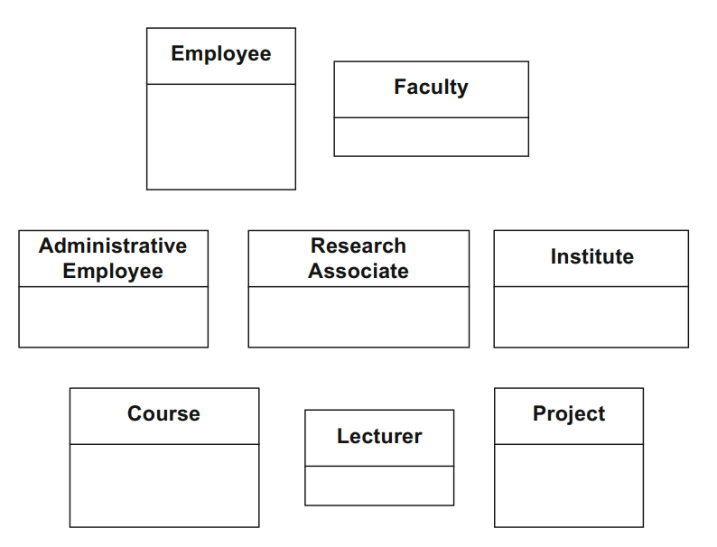

- Identificación de atributos

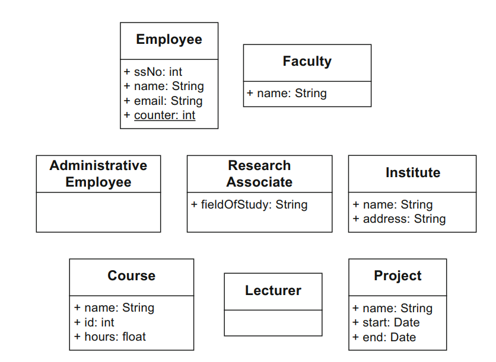

- Identificación de relaciones

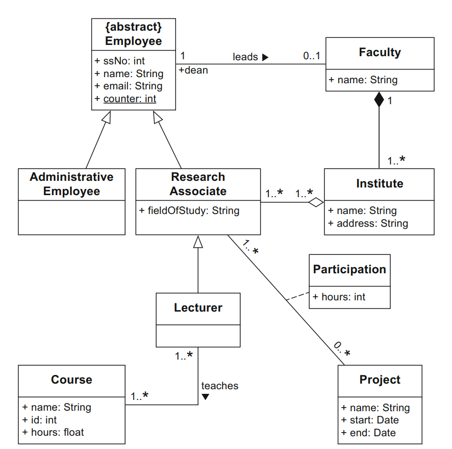

Diagrama de casos de uso

Caso de uso

Un caso de uso describe una funcionalidad del sistema a ser desarrollado. No conlleva una descripción de implementación o detalles internos del sistema.

El caso de uso producirá un beneficio tangible a uno o más actores que se comunican con el sistema a través de un caso de uso.

Normalmente, un caso de uso se representa mediante una elipse con el nombre del mismo en su interior.

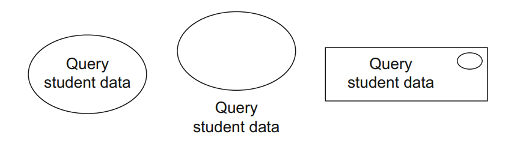

Generalmente, un caso de uso será lanzado (disparado) en el sistema por un actor externo al sistema.

El conjunto de todos los casos de uso que proporciona un sistema se representan rodeadas por un rectángulo con el nombre del sistema. El rectángulo va a representar las fronteras del sistema frente a los actores externos que hacen uso de los casos de uso.

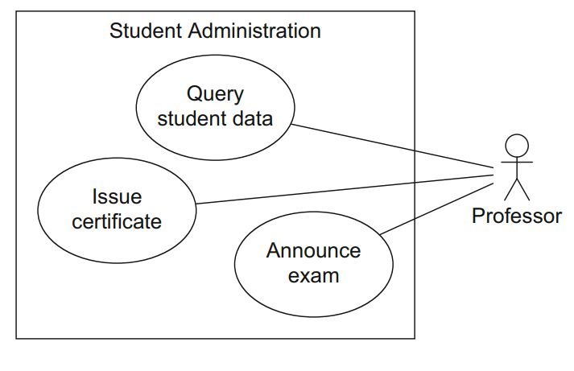

Actores

Representa quién trabaja o interactúa con el sistema.

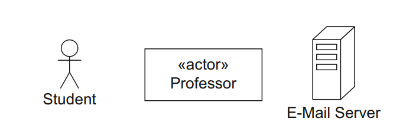

Los actores pueden ser activos y pasivos:

- activo → inicia la ejecución del caso de uso.
- pasivo → proporciona funcionalidad para la ejecución del caso de uso.

Los actores también pueden ser primarios o secundarios:

- primario → recibe un beneficio de la ejecución del caso de uso.
- secundario → no recibe un beneficio directo de la ejecución del caso de uso.

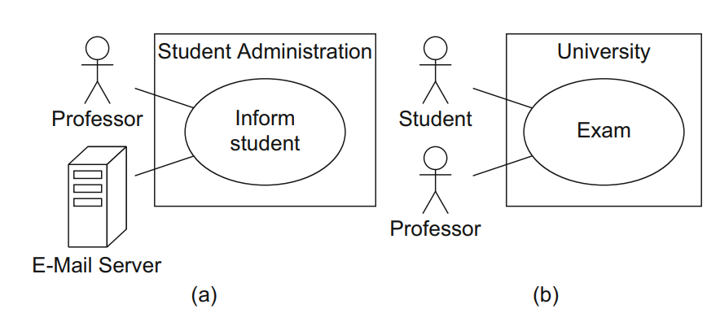

- Profesor es un actor activo y E-mail Server (servicio externo al sistema) es un actor pasivo. Aparte, Profesor es un actor humano, mientras que e-mail server es un actor no humano.
- Profesor es un actor secundario y Estudiante es un actor primario

Asociaciones

Los casos de uso se conectan con los actores mediante líneas sólidas.

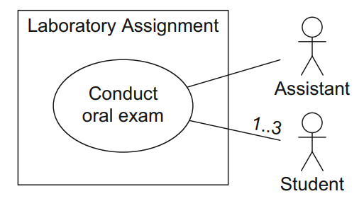

Si no se especifica multiplicidad en un extremo se considera 1.

Destacar que los actores no representan usuarios específicos, sino, más bien, roles que los usuarios pueden adoptar.

Relaciones entre los actores

Puede haber relaciones de Generalización o Herencia entre actores

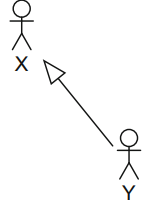

Cuando un actor Y hereda de un actor X, Y está involucrado en todos los casos de uso donde se involucra X.ç

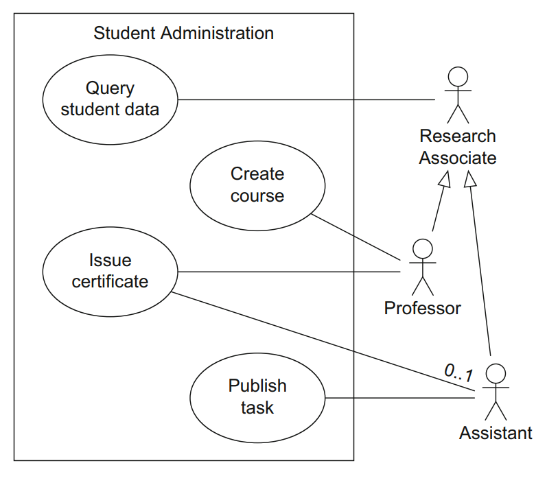

Ejemplificar la diferencia entre actores con herencia común y sin herencia.

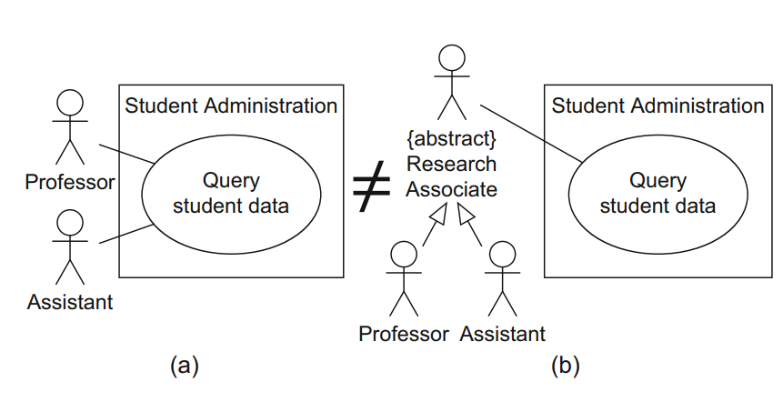

- Ambos actores Profesor y Asistente deben participar en el caso de uso.
- Cada actor puede participar individualmente en el caso de uso al heredar al actor abstracto (actor del cual no va a existir una instancia).

Relaciones entre casos de uso

include extend

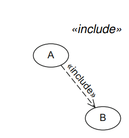

Si un caso de uso A incluye (include) un caso de uso B, entonces el comportamiento de B está incluido en A.

A se refiere como el caso de uso BASE, mientras que B se refiere como el caso de uso INCLUIDO en BASE.

A siempre requerirá de la funcionalidad de B para ejecutarse, mientras que B podrá ejecutarse por su cuenta, independientemente de A.

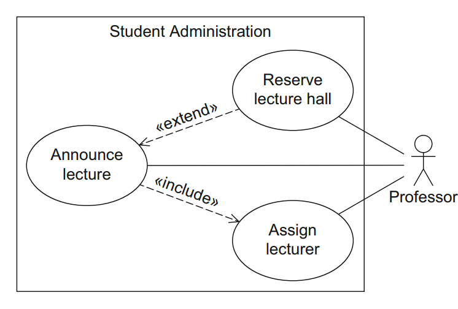

Cuando se anuncia una lección es obligatorio (está incluido) asignar un docente. No obstante, asignar un docente puede ejecutarse para un anuncio de lección sin realizar de nuevo el anuncio.

extend

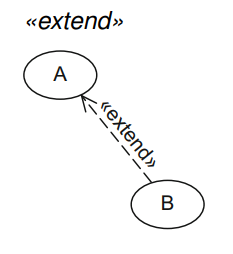

A será el caso BASE mientras que B el que extiende.

En esta relación ambos casos de uso pueden ejecutarse independientemente uno de otro

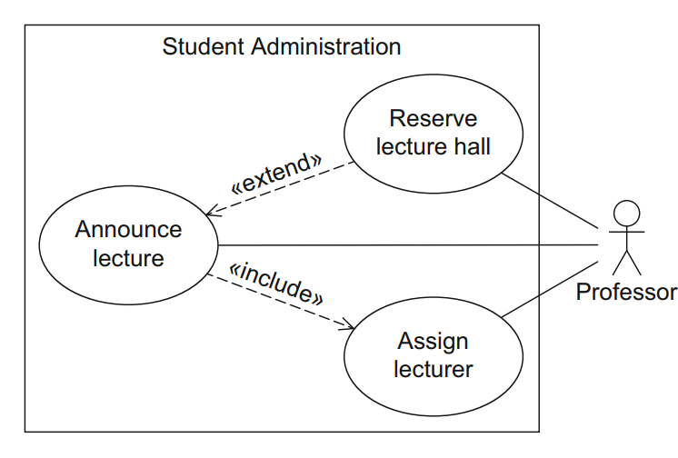

Generalización

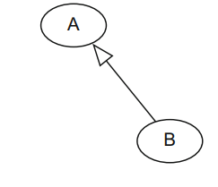

Si A generaliza el caso de uso de B, entonces B hereda el comportamiento de A, que B puede extender o sobreescribir. B también hereda todas las relaciones de A.

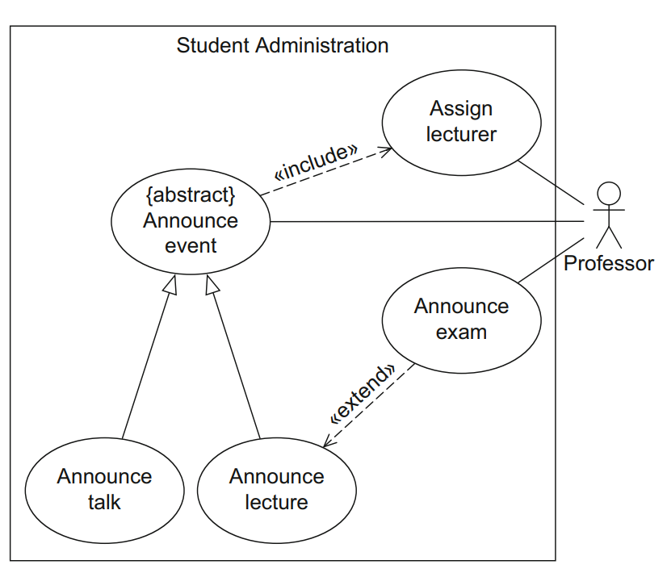

Identificación de actores:

Quién usa los principales casos de uso?

Quién necesita el soporte del sistema para su trabajo diario?

Quién es responsable de la administración del sistema?

Cuáles son los dispositivos/softwares externos al sistema con los cuales el sistema debe comunicarse?

Quién tiene interés en losl resultados del sistema?

Identificación de casos de uso -preguntas a realizar a los actores:

Cuáles son las principales tareas que el actor debe realizar?

Desea el actor consultar o modificar información almacenada en el sistema?

Desea el actor informar al sistema de cambios ocurridos en otros sistemas?

Debería el actor ser informado de eventos inesperados en el sistema?

Descripción del caso de uso

En la descripción de casos de uso de sistemas de grandes dimensiones se hace necesario mantener los nombres de los casos de uso cortos para mayor claridad. Por este motivo se complementa con una descripción, como la descripción estructurada de Cockburn:

- Nombre
- Descripción corta
- Precondición: prerrequisito para correcta ejecución del caso de uso.
- Postcondición: estado del sistema después de correcta ejecución del caso de uso.
- Situaciones de error: errores relevantes para el dominio del problema.
- Estado del sistema cuando ocurre un error.
- Actores que se comunican con el caso de uso.
- Tiggers: eventos los cuales inician/lanzan el caso de uso.
- Proceso estándar: pasos individuales para ser realizados.
- Procesos alternativos: desviaciones del proceso estándar.

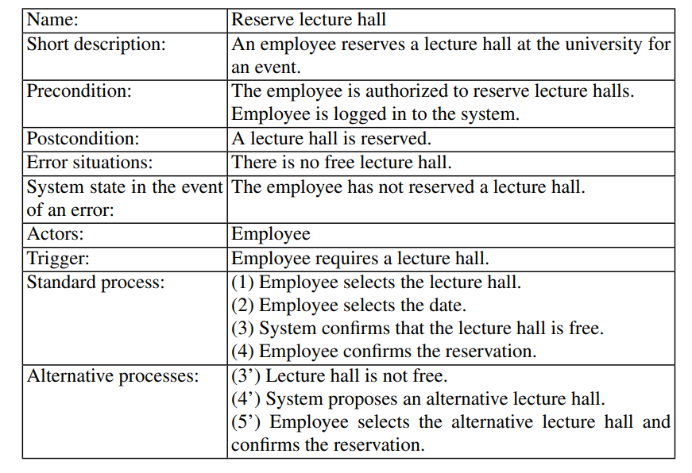